# Class 6 Hands-on

Gary Le

April 20, 2018

```r
# Can you improve this analysis code?
library(bio3d)
s1 <- read.pdb("4AKE") # kinase with drug
```

```
##   Note: Accessing on-line PDB file
```

```r
s2 <- read.pdb("1AKE") # kinase no drug
```

```
##   Note: Accessing on-line PDB file
##    PDB has ALT records, taking A only, rm.alt=TRUE
```

```r
s3 <- read.pdb("1E4Y") # kinase with drug
```

```
##   Note: Accessing on-line PDB file
```

```r
s1.chainA <- trim.pdb(s1, chain="A", elety="CA")
s2.chainA <- trim.pdb(s2, chain="A", elety="CA")
s3.chainA <- trim.pdb(s1, chain="A", elety="CA")

s1.b <- s1.chainA$atom$b
s2.b <- s2.chainA$atom$b
s3.b <- s3.chainA$atom$b

plotb3(s1.b, sse=s1.chainA, typ="l", ylab="Bfactor")
```

[output not shown]

```r
plotb3(s2.b, sse=s2.chainA, typ="l", ylab="Bfactor")
```

[output not shown]

```r
plotb3(s3.b, sse=s3.chainA, typ="l", ylab="Bfactor")
```

[output not shown]

Code snippet of main workflow

```r
library(bio3d)
#Input:
s1 <- read.pdb("4AKE")
```

```
##   Note: Accessing on-line PDB file
```

```r
#Manipulating Input:
s1.chainA <- trim.pdb(s1, chain="A", elety="CA")
s1.b <- s1.chainA$atom$b

#Output:
plotb3(s1.b, sse=s1.chainA, typ="l", ylab="Bfactor")
```

[output not shown]

Function of above code v1

```r
library(bio3d)

graph_protein <- function(accession) {
  #Purpose:
  #  Graphs the B-Factor of each Alpha-Carbon (CA) of a protein with Secondary Structure
  #  overlayed.
  #  B-Factor is the uncertainty of protein atom position in X-ray crystallography i.e. how    #  much the position of the protein wiggles.

  #Inputs:
  #  accession: Takes the PDB accession number of a protein

  #Outputs:
  #  Plots the CA position vs. B-Factor of protein w/ sse

  s <- read.pdb(accession)

  #Trim the large PDB object and limits to alpha-carbons of Chain A
  s.chainA <- trim.pdb(s, chain="A", elety="CA")

  #Access the B-factors of each alpha-carbon
  s.b <- s.chainA$atom$b

  #Plot the B-factor against the Secondary Structure Element (SSE) of Chain A
  plotb3(s.b, sse=s.chainA, typ="l", ylab="Bfactor")

}
```

Testing function v1 to see if output matches the code snippet.

```r
graph_protein("4AKE")
```

[output not shown]

```
##   Note: Accessing on-line PDB file
```

Testing function on a vector of inputs Errors: Cannot take input vector of length > 1. i.e. Function is not vectorized.

```r
#graph_protein(c("4AKE","1AKE","1E4Y"))
```

```
##   Note: Accessing on-line PDB file
```

```
##   Note: Accessing on-line PDB file
```

```
##    PDB has ALT records, taking A only, rm.alt=TRUE
```

```
##   Note: Accessing on-line PDB file
```

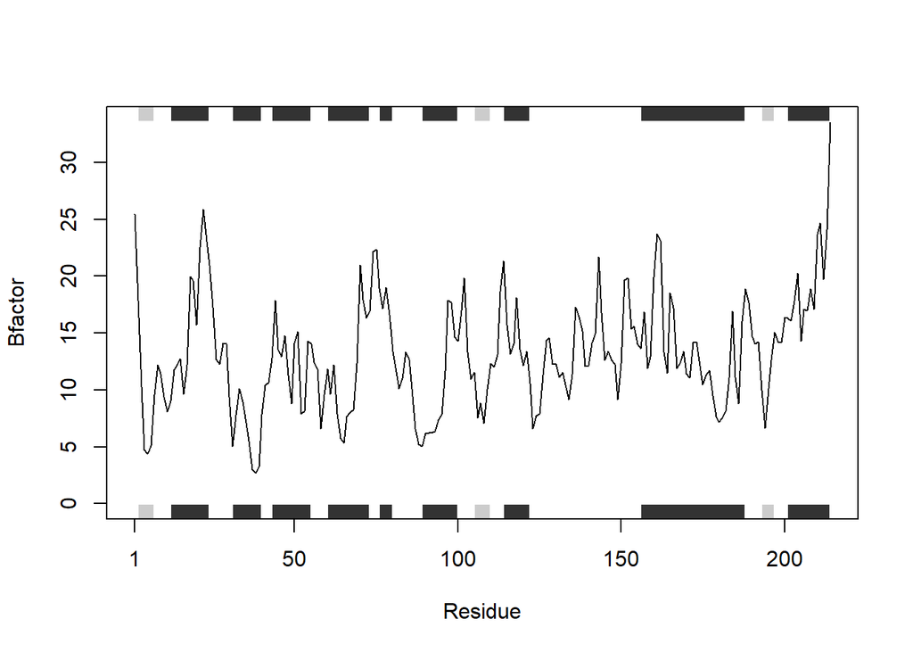

```r
#Goal
#graph_multi_prot <- function(){blah}

test_array <- c("4AKE","1AKE","1E4Y")

for (protein in test_array) {
  graph_protein(protein)
}
```

Vectorized Bfactor Graph function V1

```r
bfactor_prot_graph <- function(accession_vectors) {
  #Purpose:
  #  Graph Residue Bfactors of multiple proteins

  #Inputs:
  #  accession_vector = vector of stringified PDB accession IDs

  for (protein in accession_vectors) {
    graph_protein(protein)
  }
}
```

Better atomization of functions for increased modularity

```r
get_bfactor <- function(accession) {
  #Purpose:
  #  Return the bfactor for each residue of a PDB accession ID

  #Inputs:
  #  accession: Takes the PDC accession number of a protein

  #Outputs:
  #  Vector of B-Factor of each protein residue stored at its corresponding index

  #Reading PDB accession ID to retrieve data.
  s <- read.pdb(accession)

  #Trim the large PDB object and limits to alpha-carbons of Chain A
  s.chainA <- trim.pdb(s, chain="A", elety="CA")

  #Access the B-factors of each alpha-carbon
  s.b <- s.chainA$atom$b

  return(s.b)
}
```

Testing new function. Note: not vectorized

```r
get_bfactor("4AKE")
```

```
##   Note: Accessing on-line PDB file
```

```
##   [1]  29.02  18.44  16.20  19.67  20.26  20.55  17.05  22.13  26.71  33.05
##  [11]  30.66  32.73  25.61  33.19  41.03  24.09  16.18  19.14  29.19  14.79
##  [21]  19.63  28.54  27.49  32.56  17.13  15.50   6.98  24.07  24.00  23.94
##  [31]  30.70  24.70  32.84  34.60  33.01  44.60  50.74  57.32  47.04  67.13
##  [41]  81.04  75.20  59.68  55.63  45.12  39.04  44.31  38.21  43.70  44.19
##  [51]  47.00  48.67  41.54  50.22  45.07  49.77  52.04  44.82  39.75  35.79
##  [61]  38.92  37.93  27.18  26.86  27.53  31.16  27.08  23.03  28.12  24.78
##  [71]  24.22  18.69  40.67  38.08  55.26  46.29  26.25  37.14  27.50  16.86
##  [81]  27.76  19.27  22.22  26.70  25.52  21.22  15.90  15.84  22.44  19.61
##  [91]  21.23  21.79  17.64  22.19  22.73  16.80  23.25  35.95  24.42  20.96
## [101]  20.00  25.99  24.39  17.19  12.16  17.35  24.97  14.08  22.01  22.26
## [111]  22.78  27.47  30.49  32.02  20.90  27.03  23.84  44.37  42.47  33.48
## [121]  44.56  56.67  60.18  66.62  59.95  70.81  88.63 100.11  86.60  85.80
## [131]  77.48  68.13  52.66  45.34  52.43  60.90  62.64  72.19  66.75  58.73
## [141]  74.57  79.29  79.53  76.58  66.40  64.76  70.48  74.84  70.11  74.82
## [151]  78.61  78.24  66.70  66.10  67.01  72.28  80.64  68.54  43.23  51.24
## [161]  45.72  61.60  45.61  42.57  41.03  41.02  33.34  19.48  34.38  33.11
## [171]  25.48  29.68  40.71  32.91  24.41  19.20  15.43  19.93  20.66  12.72
## [181]  21.40  18.21  26.68  34.50  25.77  26.52  36.85  31.05  39.84  48.03
## [191]  23.04  29.57  23.00  23.80  26.59  25.49  23.25  19.89  32.37  30.97
## [201]  42.16  29.64  29.69  33.15  26.38  23.17  29.35  32.80  25.92  38.01
## [211]  45.95  44.26  44.35  70.26
```

```r
get_bfactor("1AKE")
```

```
##   Note: Accessing on-line PDB file
```

```
##    PDB has ALT records, taking A only, rm.alt=TRUE
```

```
##   [1] 37.14 25.76 23.90 17.83 19.86 21.75 20.21 16.92 17.47 18.35 18.31
##  [12] 20.57 14.56 17.87 11.87 24.63 21.29 35.13 29.68 23.96 32.34 35.34
##  [23] 35.64 38.91 29.00 36.55 28.83 27.15 30.28 28.13 19.90 21.95 25.07
##  [34] 16.15 18.35 21.19 27.13 28.55 21.10 38.88 33.63 29.51 29.21 33.01
##  [45] 20.92 17.17 25.84 29.80 16.89 24.66 35.62 23.52 23.37 34.41 25.96
##  [56] 16.79 20.20 23.72 23.29 25.23 19.81 19.00 20.21 22.62 21.40 23.47
##  [67] 23.20 20.21 25.90 30.58 28.25 37.60 44.66 54.46 91.10 92.02 86.85
##  [78] 80.21 68.72 42.01 27.69 23.06 21.98 18.60 20.17 15.06 14.20 23.07
##  [89] 20.36 25.76 17.02 13.71 23.88 26.72 22.58 24.51 45.23 38.07 36.97
## [100] 35.17 37.83 43.69 29.14 24.56 25.20 19.27 20.88 18.27 16.96 21.38
## [111] 18.33 23.18 21.15 21.97 22.63  9.74 16.71 26.18 30.39 22.95 25.51
## [122] 20.28 16.86 21.94 20.59 21.64 27.42 35.72 23.47 31.57 23.71 19.01
## [133] 21.52 19.40 24.32 34.28 23.96 23.14 26.60 24.94 28.49 28.18 41.64
## [144] 23.85 28.67 28.76 35.16 35.46 28.74 26.99 31.74 40.41 33.73 25.57
## [155] 29.13 29.74 36.32 22.58 22.82 46.67 29.44 25.40 17.27 20.38 21.55
## [166] 19.19 15.89 18.37 30.51 18.47 11.70 18.45 24.75 16.63 20.80 19.62
## [177] 22.56 19.87 20.22 21.16 22.13 20.66 22.82 32.86 26.04 20.60 44.44
## [188] 35.28 38.03 28.46 29.10 30.19 26.17 22.71 23.39 23.44 16.27 21.26
## [199] 24.67 19.12 23.26 21.75 24.59 27.26 22.63 26.40 31.60 29.57 30.90
## [210] 32.29 46.86 41.73 49.31 66.76
```

Graphing Protein v2 with more descriptive name

```r
graph_bfactor <- function(accession) {
  #Purpose:
  #  Graphs the B-Factor of each Alpha-Carbon (CA) of a protein with Secondary Structure
  #  overlayed.
  #  B-Factor is the uncertainty of protein atom position in X-ray crystallography i.e. how    #  much the position of the protein wiggles.

  #Inputs:
  #  accession: Takes the PDC accession number of a protein

  #Outputs:
  #  Plots the CA position vs. B-Factor of protein w/ sse

  #Getting B-factors of each residue
  get_bfactor(accession = accession)

  #Plot the B-factor of each residue with the Secondary Structure Element (SSE) of Chain A
  plotb3(s.b, sse=s.chainA, typ="l", ylab="Bfactor")

}
```

Testing ways to iterate through a vector of B-Factors

```r
  for (protein in 2:length(test_array)) {
    get_bfactor(test_array[protein])
  }
```

```
##   Note: Accessing on-line PDB file
```

```
##    PDB has ALT records, taking A only, rm.alt=TRUE
##   Note: Accessing on-line PDB file
```

Modifying the above function to improve datahandling.

```r
bfactor_prot_graph2 <- function(accession_vectors,
                                individ.plot = TRUE) {
  #Purpose:
  #  Graph Residue Bfactors of multiple proteins

  #Inputs:
  #  accession_vectors = vector of stringified PDB accession IDs
  #  individ.plot = Boolean that graphs individual graphs of each protein

  #Outputs:
  #  Composite plot of the B-factor of each residue of all proteins listed in
  #  accession_vectors
  #
  #  Individual plots of the B-Factor of each residue for all proteins in accession_vectors

  #Graph the B-factor of the 1st PDB accession ID to initialize the plot
  s0 <- get_bfactor(accession_vectors[1])
  plot(s0, typ='l', xlab = "Residue", ylab = "B-Factor", main = "Composite")

  #Determining remaining lines to be plotted
  remaining <- length(accession_vectors)

  #Add the subsequent lines
  for (protein in 2:remaining) {
    s <- get_bfactor(accession_vectors[protein])
    lines(s, typ='l', col = c(protein))
  } #end of adding lines

  ##Graphing individual plots
  if(individ.plot){
    for (protein in accession_vectors) {
      graph_protein(protein)
    }
  } #end of individual plots
} #end of function
```

```
##   Note: Accessing on-line PDB file
```

```
##   Note: Accessing on-line PDB file
```

```
##    PDB has ALT records, taking A only, rm.alt=TRUE
##   Note: Accessing on-line PDB file
```

```
##   Note: Accessing on-line PDB file
```

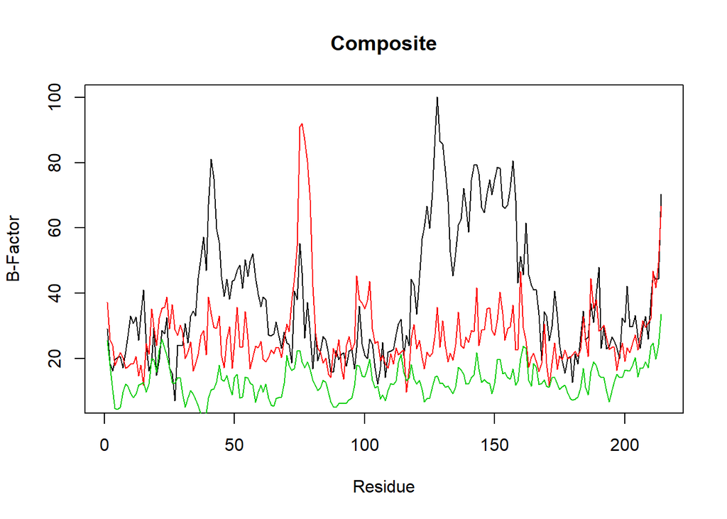

```
##   Note: Accessing on-line PDB file
```

```
##    PDB has ALT records, taking A only, rm.alt=TRUE
```

```
##   Note: Accessing on-line PDB file
```

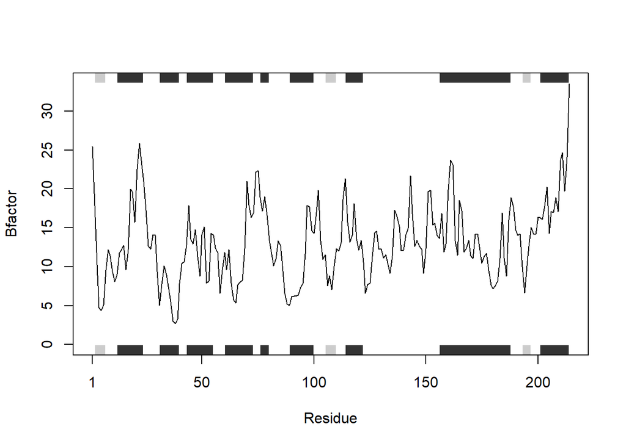

```r
bfactor_prot_graph2(test_array)
```

### Homework: Other ways to compare B-Factor of Protein Residues

Useful functions:

```r
#hclust() gives a graphable object that returns a hierarchical structure of deviations between objects

#dist() computes a distance matrix between rows of a data matrix i.e. how different is one residue of one protein to the same # residue of another protein

#rbind() ol' reliable. Binds the rows of multiple matrices together. In this case, makes the different protein residues comparable
```

Hardcode test:

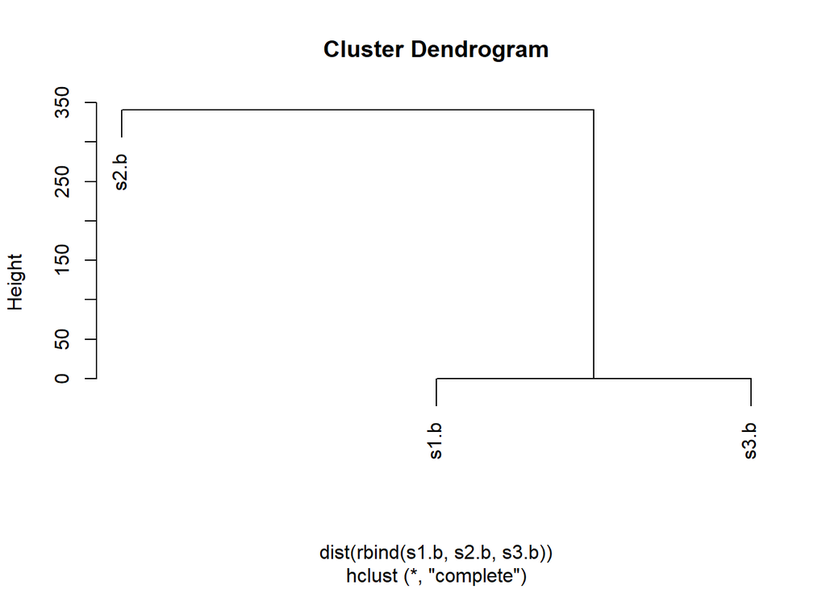

```r
hc <- hclust( dist( rbind(s1.b, s2.b, s3.b) ) )
plot(hc)
```

Try same results with hclustplot() bio3d function

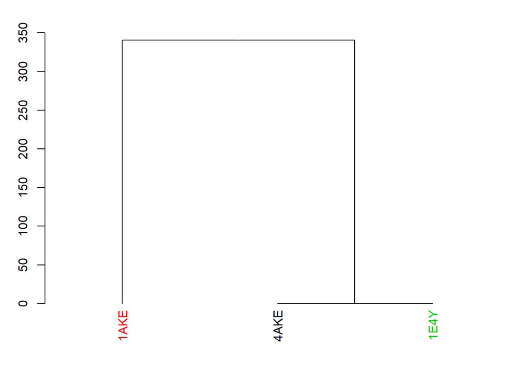

```r
hc <- hclust( dist( rbind(s1.b, s2.b, s3.b) ) )

#Changes the label of each index to be the accession ID rather than variable
hc$labels <- test_array

#hclustplot(hc)  doesn't work. Missing a k that needs to be btwn 1-3?

hclustplot(hc,3,hc$height) #plots with 3 colors
```